# Exercises

Sergio Rodriguez Llana

5/19/2020

**GitHub respository:** https://github.com/SergioRLL/SRL_Omics_Techniques.git

# Exercise 1

- **Title**: Early postnatal expression data from mouse skeletal muscle stem cells
- **GEO identifier (GSE)**: GSE65927
- **Summary of the study**: Satellite cells are the primary source of stem cells for skeletal muscle growth and regeneration. Since adult stem cell maintenance involves a fine balance between intrinsic and extrinsic mechanisms, the researchers performed genome-wide chronological expression profiling to identify the transcriptomic changes involved during early postnatal growth till acquisition of satellite cell quiescence.
- **Experimental design**: Muscle samples were isolated from the trunk of Pax3GFP/+ mice. After digestion, GFP cells were purified via FACS and process for RNA extraction and hybridization on Affymetrix microarrays (Affymetrix Mouse Genome 430 2.0 Arrays). The different ages selected for sample isolation were P1-P12-P28 (P, postnatal days), covering proliferant and quiescent satellite cells. The three stages were done in triplicate for P28 and 4 times for P1-P12, so 11 samples included in the microarray.

```r
require(GEOquery)
gse <- getGEO("GSE65927")
```

```
## Found 1 file(s)
```

```
## GSE65927_series_matrix.txt.gz
```

```
## File stored at:
```

```
## /tmp/RtmpzMaMP9/GPL1261.soft
```

```r
names(gse)
```

```
## [1] "GSE65927_series_matrix.txt.gz"
```

```r
gse[[1]]
```

```
## ExpressionSet (storageMode: lockedEnvironment)
## assayData: 45101 features, 11 samples
##   element names: exprs
## protocolData: none
## phenoData
##   sampleNames: GSM1611267 GSM1611268 ... GSM1611277 (11 total)
##   varLabels: title geo_accession ... tissue:ch1 (43 total)
##   varMetadata: labelDescription
## featureData
##   featureNames: 1415670_at 1415671_at ... AFFX-TrpnX-M_at (45101 total)
##   fvarLabels: ID GB_ACC ... Gene Ontology Molecular Function (16 total)
##   fvarMetadata: Column Description labelDescription
## experimentData: use 'experimentData(object)'
##   pubMedIds: 25742797
## Annotation: GPL1261
```

```r
esetFromGEO <- gse[[1]]
```

## Expression Matrix:

```r
require(Biobase)
head(exprs(esetFromGEO))
```

```
##              GSM1611267 GSM1611268 GSM1611269 GSM1611270 GSM1611271 GSM1611272
## 1415670_at     8.990429   9.137829   9.106333   9.223730   9.497992   9.187752
## 1415671_at     9.018834   9.024178   8.517641   8.600947   9.273806   9.039500
## 1415672_at     9.901563   9.992012   9.486537   9.542342  10.055822  10.158139
## 1415673_at     5.696746   6.411152   5.861409   6.176357   6.688459   6.208029
## 1415674_a_at   8.096755   8.076251   8.274019   8.278129   8.167868   7.928214
## 1415675_at     8.573933   8.701995   8.650948   8.714725   8.420837   8.215975
##              GSM1611273 GSM1611274 GSM1611275 GSM1611276 GSM1611277
## 1415670_at     9.375778   9.850090  10.164990   9.621056   9.854083
## 1415671_at     8.838924   9.308572   9.491139   9.591581   9.254252
## 1415672_at     9.800728  10.117308   9.911234  10.012373   9.877343
## 1415673_at     6.664490   7.040977   7.032024   7.314067   7.614698
## 1415674_a_at   8.131195   8.667981   8.754175   9.063867   9.169184
## 1415675_at     8.583586   8.674828   8.781600   8.833954   8.694823
```

```r
dim(exprs(esetFromGEO))
```

```
## [1] 45101    11
```

Looking at the Expression Matrix dimensions we see that there are 45101 rows and 11 columns. Columns correspond to different samples.

```r
summary(exprs(esetFromGEO))
```

```
##    GSM1611267        GSM1611268        GSM1611269       GSM1611270
##  Min.   : 0.3206   Min.   : 0.4759   Min.   : 0.181   Min.   :-0.1274
##  1st Qu.: 4.3856   1st Qu.: 4.3862   1st Qu.: 4.355   1st Qu.: 4.3465
##  Median : 5.5753   Median : 5.5753   Median : 5.521   Median : 5.5336
##  Mean   : 6.0718   Mean   : 6.0857   Mean   : 5.990   Mean   : 6.0067
##  3rd Qu.: 7.4535   3rd Qu.: 7.4833   3rd Qu.: 7.359   3rd Qu.: 7.3960
##  Max.   :14.0580   Max.   :14.2280   Max.   :13.512   Max.   :13.9180
##    GSM1611271        GSM1611272        GSM1611273        GSM1611274
##  Min.   :-0.2908   Min.   :-0.7848   Min.   :-0.4694   Min.   : 0.3465
##  1st Qu.: 4.3610   1st Qu.: 4.3577   1st Qu.: 4.3164   1st Qu.: 4.3128
##  Median : 5.5490   Median : 5.5484   Median : 5.5059   Median : 5.5225
##  Mean   : 6.0937   Mean   : 6.0973   Mean   : 6.0209   Mean   : 6.0800
##  3rd Qu.: 7.5303   3rd Qu.: 7.5045   3rd Qu.: 7.4607   3rd Qu.: 7.5852
##  Max.   :14.2606   Max.   :14.2600   Max.   :13.6918   Max.   :14.1184
##    GSM1611275       GSM1611276       GSM1611277
##  Min.   : 2.094   Min.   : 1.654   Min.   : 1.677
##  1st Qu.: 4.255   1st Qu.: 4.258   1st Qu.: 4.248
##  Median : 5.505   Median : 5.501   Median : 5.522
##  Mean   : 6.061   Mean   : 6.055   Mean   : 6.090
##  3rd Qu.: 7.593   3rd Qu.: 7.577   3rd Qu.: 7.657
##  Max.   :14.519   Max.   :14.576   Max.   :14.122
```

It seems that the data is normalzied as the mean and the meadian has a close vaule.

## PhenoData:

```r
head(pData(esetFromGEO))
```

```
##                                     title geo_accession                status
## GSM1611267  Postnatal P1, biological rep1    GSM1611267 Public on Apr 21 2015
## GSM1611268  Postnatal P1, biological rep2    GSM1611268 Public on Apr 21 2015
## GSM1611269  Postnatal P1, biological rep3    GSM1611269 Public on Apr 21 2015
## GSM1611270  Postnatal P1, biological rep4    GSM1611270 Public on Apr 21 2015
## GSM1611271 Postnatal P12, biological rep1    GSM1611271 Public on Apr 21 2015
## GSM1611272 Postnatal P12, biological rep2    GSM1611272 Public on Apr 21 2015
##            submission_date last_update_date type channel_count
## GSM1611267     Feb 13 2015      Apr 21 2015  RNA             1
## GSM1611268     Feb 13 2015      Apr 21 2015  RNA             1
## GSM1611269     Feb 13 2015      Apr 21 2015  RNA             1
## GSM1611270     Feb 13 2015      Apr 21 2015  RNA             1
## GSM1611271     Feb 13 2015      Apr 21 2015  RNA             1
## GSM1611272     Feb 13 2015      Apr 21 2015  RNA             1
##                                                                           source_name_ch1
## GSM1611267  mouse trunk muscles including skeletal muscle proliferant satellite cells, P1
## GSM1611268  mouse trunk muscles including skeletal muscle proliferant satellite cells, P1
## GSM1611269  mouse trunk muscles including skeletal muscle proliferant satellite cells, P1
## GSM1611270  mouse trunk muscles including skeletal muscle proliferant satellite cells, P1
## GSM1611271 mouse trunk muscles including skeletal muscle proliferant satellite cells, P12
## GSM1611272 mouse trunk muscles including skeletal muscle proliferant satellite cells, P12
##            organism_ch1         characteristics_ch1
## GSM1611267 Mus musculus strain/background: C57BL/6J
## GSM1611268 Mus musculus strain/background: C57BL/6J
## GSM1611269 Mus musculus strain/background: C57BL/6J
## GSM1611270 Mus musculus strain/background: C57BL/6J
## GSM1611271 Mus musculus strain/background: C57BL/6J
## GSM1611272 Mus musculus strain/background: C57BL/6J
##                    characteristics_ch1.1
## GSM1611267 genotype/variation: Pax3GFP/+
## GSM1611268 genotype/variation: Pax3GFP/+
## GSM1611269 genotype/variation: Pax3GFP/+
## GSM1611270 genotype/variation: Pax3GFP/+
## GSM1611271 genotype/variation: Pax3GFP/+
## GSM1611272 genotype/variation: Pax3GFP/+
##                                                                  characteristics_ch1.2
## GSM1611267 tissue: trunk muscles including skeletal muscle proliferant satellite cells
## GSM1611268 tissue: trunk muscles including skeletal muscle proliferant satellite cells
## GSM1611269 tissue: trunk muscles including skeletal muscle proliferant satellite cells
## GSM1611270 tissue: trunk muscles including skeletal muscle proliferant satellite cells
```

[output cut: 148 more lines]

```
## GSM1611272          45101 postnatal day 12              Pax3GFP/+
##            strain/background:ch1
## GSM1611267              C57BL/6J
## GSM1611268              C57BL/6J
## GSM1611269              C57BL/6J
## GSM1611270              C57BL/6J
## GSM1611271              C57BL/6J
## GSM1611272              C57BL/6J
##                                                                     tissue:ch1
## GSM1611267 trunk muscles including skeletal muscle proliferant satellite cells
## GSM1611268 trunk muscles including skeletal muscle proliferant satellite cells
## GSM1611269 trunk muscles including skeletal muscle proliferant satellite cells
## GSM1611270 trunk muscles including skeletal muscle proliferant satellite cells
## GSM1611271 trunk muscles including skeletal muscle proliferant satellite cells
## GSM1611272 trunk muscles including skeletal muscle proliferant satellite cells
```

```r
ph_data <- pData(esetFromGEO)
colnames(pData(esetFromGEO))
```

```
##  [1] "title"                   "geo_accession"
##  [3] "status"                  "submission_date"
##  [5] "last_update_date"        "type"
##  [7] "channel_count"           "source_name_ch1"
##  [9] "organism_ch1"            "characteristics_ch1"
## [11] "characteristics_ch1.1"   "characteristics_ch1.2"
## [13] "characteristics_ch1.3"   "treatment_protocol_ch1"
## [15] "growth_protocol_ch1"     "molecule_ch1"
## [17] "extract_protocol_ch1"    "label_ch1"
## [19] "label_protocol_ch1"      "taxid_ch1"
## [21] "hyb_protocol"            "scan_protocol"
## [23] "description"             "data_processing"
## [25] "data_processing.1"       "data_processing.2"
## [27] "platform_id"             "contact_name"
## [29] "contact_email"           "contact_phone"
## [31] "contact_laboratory"      "contact_department"
## [33] "contact_institute"       "contact_address"
## [35] "contact_city"            "contact_zip/postal_code"
## [37] "contact_country"         "supplementary_file"
## [39] "data_row_count"          "age:ch1"
## [41] "genotype/variation:ch1"  "strain/background:ch1"
## [43] "tissue:ch1"
```

Now I’m going to see the number of groups of the experiment (factors):

```r
ph_data$title
```

```
##  [1] "Postnatal P1, biological rep1"  "Postnatal P1, biological rep2"
##  [3] "Postnatal P1, biological rep3"  "Postnatal P1, biological rep4"
##  [5] "Postnatal P12, biological rep1" "Postnatal P12, biological rep2"
##  [7] "Postnatal P12, biological rep3" "Postnatal P12, biological rep4"
##  [9] "Postnatal P28, biological rep1" "Postnatal P28, biological rep2"
## [11] "Postnatal P28, biological rep3"
```

We have the following factors:

- A factor that is the postnatal day: (Postnatal P1, Postnatal P12 and Postnatal P28).
- A factor that corresponds to the biologial replicate: (rep1, rep2 rep3 and rep4).

Therefore we sould have a total of 12 groups. However the samples I think that do not cover all the posibilites.

## Plots:

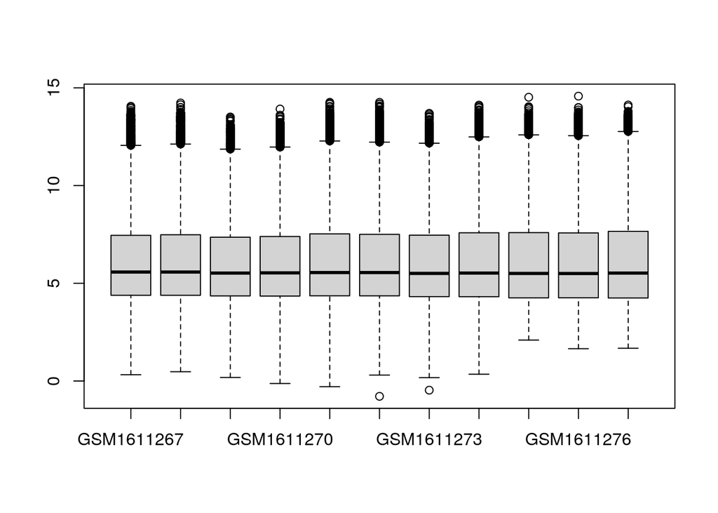

```r
boxplot(exprs(esetFromGEO))
```

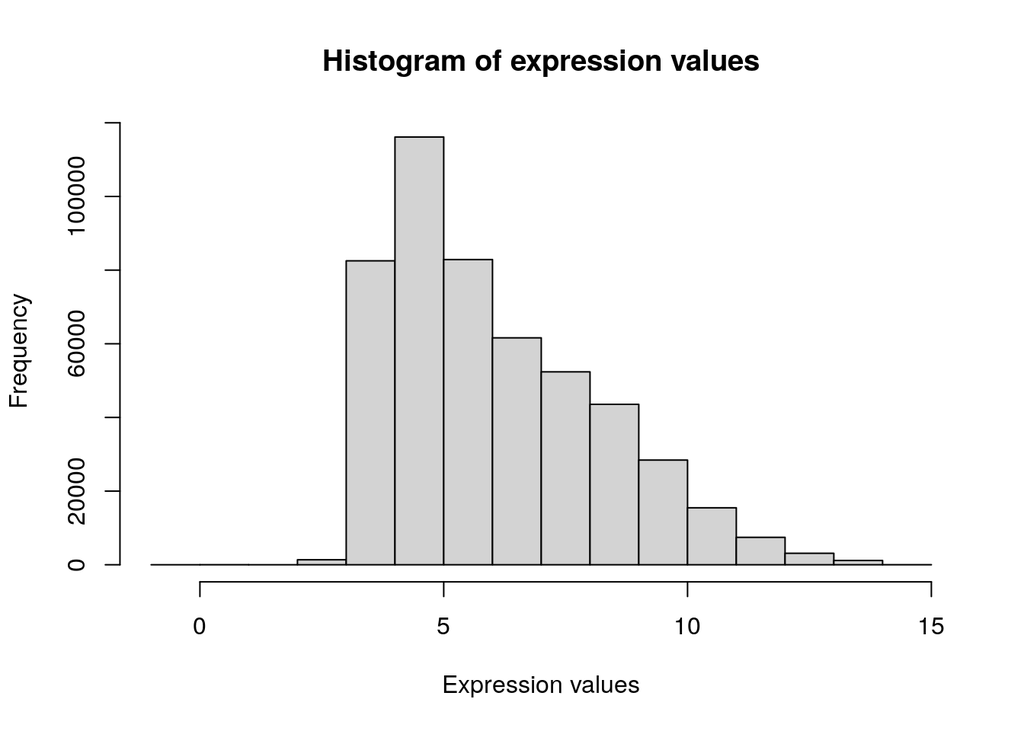

```r
hist(exprs(esetFromGEO), main = "Histogram of expression values", xlab = "Expression values")
```

We can observe that the data have similar variance. The most expressed values are arround 5.